# Lojistik Regresyon Modeli

İclal

2025-04-28

## 1. Gerekli Paketlerin Yüklenmesi ve Yüklenmesi

Lojistik regresyon için gerekli olan paketleri yükleyelim.

```r
library(glmnet)
library(cli)
library(tidyverse)
library(modelr)
library(broom)
library(ISLR)
library(pscl)
library(tibble)
library(dplyr)
```

Veri setini ISLR paketinden Default veri seti olarak alıyoruz ve genel bir inceleme yapıyoruz.

```r
data <- Default
head(data)
```

```
##   default student   balance    income
## 1      No      No  729.5265 44361.625
## 2      No     Yes  817.1804 12106.135
## 3      No      No 1073.5492 31767.139
## 4      No      No  529.2506 35704.494
## 5      No      No  785.6559 38463.496
## 6      No     Yes  919.5885  7491.559
```

```r
default <- as_tibble(ISLR::Default)
```

Veri setini %60 eğitim, %40 test olacak şekilde bölelim.

```r
set.seed(123)
sample1 <- sample(1:nrow(data),size = 0.6*nrow(data))
train <- data[sample1,]
test <- data[-sample1,]
```

glm() fonksiyonunu kullanarak, eğitim verisiyle bir lojistik regresyon modeli oluşturalım. Bu modelde, bağımlı değişken default ve bağımsız değişken olarak balance yer alacak.

```r
model1 <- glm(default ~ balance, family = "binomial", data = train)
summary(model1)
```

```
##
## Call:
## glm(formula = default ~ balance, family = "binomial", data = train)
##
## Coefficients:
##               Estimate Std. Error z value Pr(>|z|)
## (Intercept) -1.078e+01  4.720e-01  -22.83   <2e-16 ***
## balance      5.584e-03  2.877e-04   19.41   <2e-16 ***
## ---
## Signif. codes:  0 '***' 0.001 '**' 0.01 '*' 0.05 '.' 0.1 ' ' 1
##
## (Dispersion parameter for binomial family taken to be 1)
##
##     Null deviance: 1747.00  on 5999  degrees of freedom
## Residual deviance:  939.03  on 5998  degrees of freedom
## AIC: 943.03
##
## Number of Fisher Scoring iterations: 8
```

```r
#Kişinin bakiyesi 0 olduğunda (yani hiç borcu yokken) temerrüde düşme logit'i (log-olasılığı) -10.78'dir.

#balance (bakiye) 1 birim arttığında, temerrüde düşme logit değeri 0.005584 birim artıyor
```

Modelin katsayılarını inceleyelim. Lojistik regresyonda, katsayılar log-odds (logaritmik oran) şeklinde verilir. Bu katsayıları üssel hale getirelim (odds ratio).

```r
exp(coef(model1))
```

```
##  (Intercept)      balance
## 2.086999e-05 1.005599e+00
```

Buradan cıkan sonuca göre ;

Bireyin bakiyesindeki her 1 birimlik artış, temerrüde düşme olasılığını yaklaşık %0.56 oranında artırmaktadır. Başlangıç bakiyesi sıfır olan bireylerin temerrüde düşme ihtimali ise yok denecek kadar düşüktür.

Modelden elde edilen tahminlerin olasılıklarını hesaplayalım. Bu işlemi type = “response” parametresi ile yapıyoruz.

```r
predict(model1, data.frame(balance = c(1000, 2000)), type = "response")
```

```
##           1           2
## 0.005522723 0.596404444
```

Model sonuçlarına göre, kredi kartı bakiyesi 1000 olan bir bireyin temerrüde düşme ihtimali yaklaşık %0.55 iken, bakiyesi 2000 olan bir bireyin temerrüde düşme ihtimali %59.64’e çıkmaktadır. Bu durum, bakiye arttıkça temerrüde düşme riskinin belirgin şekilde arttığını göstermektedir.

Bir kategorik değişken olan student ile bir model daha kurabiliriz. Bu modelde student değişkenini bağımsız değişken olarak kullanacağız.

```r
model2 <- glm(default ~ student, family = "binomial", data = train)
summary(model2)
```

```
##
## Call:
## glm(formula = default ~ student, family = "binomial", data = train)
##
## Coefficients:
##             Estimate Std. Error z value Pr(>|z|)
## (Intercept) -3.50038    0.09078 -38.558  < 2e-16 ***
## studentYes   0.38987    0.14952   2.607  0.00912 **
## ---
## Signif. codes:  0 '***' 0.001 '**' 0.01 '*' 0.05 '.' 0.1 ' ' 1
##
## (Dispersion parameter for binomial family taken to be 1)
##
##     Null deviance: 1747.0  on 5999  degrees of freedom
## Residual deviance: 1740.4  on 5998  degrees of freedom
## AIC: 1744.4
##
## Number of Fisher Scoring iterations: 6
```

```r
exp(coef(model2))
```

```
## (Intercept)  studentYes
##  0.03018595  1.47679036
```

studentYes değişkeninin p-değeri 0.00912, yani 0.01’den küçük.

Bu nedenle student değişkeni, istatistiksel olarak anlamlıdır. Yani gerçekten “öğrenci olma” durumu temerrüde düşme riskini etkiliyor diyebiliriz.

Öğrenci olmayan bireylerin temerrüde düşme olasılık oranı oldukça düşük (%3 civarında) iken, öğrenci olan bireylerin temerrüde düşme olasılık oranı öğrenci olmayanlara kıyasla yaklaşık %47.7 daha fazladır.

# Çoklu Lojistik Regresyon Modeli

Birden fazla bağımsız değişken kullanarak, çoklu lojistik regresyon modelini kuruyoruz. Bu modelde balance, income, ve student değişkenlerini kullanacağız.

```r
model3 <- glm(default ~ balance + income + student, family = "binomial", data = train)
summary(model3)
```

```
##
## Call:
## glm(formula = default ~ balance + income + student, family = "binomial",
##     data = train)
##
## Coefficients:
##               Estimate Std. Error z value Pr(>|z|)
## (Intercept) -1.101e+01  6.467e-01 -17.025   <2e-16 ***
## balance      5.783e-03  3.001e-04  19.268   <2e-16 ***
## income       4.274e-06  1.081e-05   0.395   0.6925
## studentYes  -5.641e-01  3.081e-01  -1.831   0.0672 .
## ---
## Signif. codes:  0 '***' 0.001 '**' 0.01 '*' 0.05 '.' 0.1 ' ' 1
##
## (Dispersion parameter for binomial family taken to be 1)
##
##     Null deviance: 1747.00  on 5999  degrees of freedom
## Residual deviance:  926.42  on 5996  degrees of freedom
## AIC: 934.42
##
## Number of Fisher Scoring iterations: 8
```

```r
exp(coef(model3))
```

```
##  (Intercept)      balance       income   studentYes
## 1.652913e-05 1.005800e+00 1.000004e+00 5.688898e-01
```

Balance değişkeni, temerrüde düşmeyi güçlü şekilde açıklıyor (pozitif ve anlamlı). Income değişkeni anlamlı bir etkide bulunmuyor. Student değişkeni negatif etki ediyor gibi, ama anlamlılık sınırında (zayıf bir etki). Modelin AIC değeri (934.42) önceki modellerden düşük → bu model daha iyi açıklayıcı güce sahip.

Kısa bir örnek cümle ile toparlarsak: Balance değişkeni temerrüde düşme riskini anlamlı şekilde artırırken, income değişkeninin etkisi istatistiksel olarak anlamlı bulunmamıştır. Student değişkeni, temerrüde düşme olasılığını azaltıyor gibi görünmekle birlikte, bu etkinin anlamlılığı sınırlıdır.

Modellerin başarısını karşılaştırmak için, Anova testi kullanarak iki modeli karşılaştıralım.

```r
Anova <- anova(model1, model3, test = "Chisq")
Anova
```

```
## Analysis of Deviance Table
##
## Model 1: default ~ balance
## Model 2: default ~ balance + income + student
##   Resid. Df Resid. Dev Df Deviance Pr(>Chi)
## 1      5998     939.03
## 2      5996     926.42  2   12.606 0.001831 **
## ---
## Signif. codes:  0 '***' 0.001 '**' 0.01 '*' 0.05 '.' 0.1 ' ' 1
```

Balance değişkenine ek olarak income ve student değişkenlerinin modele dahil edilmesi, temerrüde düşme olasılığını açıklamada anlamlı bir iyileşme sağlamıştır (p = 0.0018).

# Pseudo R-Kare Değerleri

Her bir model için pseudo R-kare değerlerini hesaplayalım. Bu, modelin uyumunu ölçen bir değerdir.

```r
list(
  model1 = pscl::pR2(model1)["McFadden"],
  model2 = pscl::pR2(model2)["McFadden"],
  model3 = pscl::pR2(model3)["McFadden"]
)
```

```
## fitting null model for pseudo-r2
## fitting null model for pseudo-r2
## fitting null model for pseudo-r2
```

```
## $model1
##  McFadden
## 0.4624897
##
## $model2
##    McFadden
## 0.003755378
##
## $model3
##  McFadden
## 0.4697054
```

Balance değişkeni temerrüt olasılığını açıklamada oldukça güçlüdür (McFadden R² ≈ 0.46). Student değişkeni tek başına temerrüdü açıklamada etkisiz kalmıştır (McFadden R² ≈ 0.004). Balance, income ve student değişkenlerinin birlikte kullanıldığı model, en yüksek açıklayıcılığı sağlamıştır (McFadden R² ≈ 0.47).

# Test Seti Üzerinden Tahminler

Test seti üzerinde her üç modeli kullanarak tahmin yapalım. predict() fonksiyonu ile test seti üzerindeki olasılıkları hesaplayacağız.

```r
test.predicted.m1 <- predict(model1, newdata = test, type = "response")
test.predicted.m2 <- predict(model2, newdata = test, type = "response")
test.predicted.m3 <- predict(model3, newdata = test, type = "response")
```

# Model Performansı ve Doğrulama

Test seti üzerinden her model için doğruluk oranlarını ve karmaşıklık matrislerini inceleyelim.

```r
list(
  model1 = table(test$default, test.predicted.m1 > 0.5) %>% prop.table() %>% round(5),
  model2 = table(test$default, test.predicted.m2 > 0.5) %>% prop.table() %>% round(5),
  model3 = table(test$default, test.predicted.m3 > 0.5) %>% prop.table() %>% round(5)
)
```

```
## $model1
##
##         FALSE    TRUE
##   No  0.96175 0.00475
##   Yes 0.02400 0.00950
##
## $model2
##
##        FALSE
##   No  0.9665
##   Yes 0.0335
##
## $model3
##
##         FALSE    TRUE
##   No  0.96325 0.00325
##   Yes 0.02325 0.01025
```

“Model 1 ve Model 3, temerrüt eden müşterileri küçük bir oranla da olsa doğru tahmin edebilmektedir (%0.95 ve %1.025). Model 2 ise yalnızca öğrenci bilgisine dayanarak tahmin yaptığı için temerrüt eden bireyleri doğru şekilde sınıflandıramamıştır. Genel olarak, balance değişkeni modeli güçlendirmekte ve model3 (balance + income + student) en iyi doğrulama performansına sahiptir

# Karmaşıklık Matrisi ve Doğruluk

Karmaşıklık matrisi ile modelin doğruluğunu inceleyelim.

```r
predictClass <- ifelse(test.predicted.m1 > 0.5, "Yes", "No")
predictClass <- as.factor(predictClass)
caret::confusionMatrix(predictClass, reference = test$default, positive = "Yes")
```

```
## Confusion Matrix and Statistics
##
##           Reference
## Prediction   No  Yes
##        No  3847   96
##        Yes   19   38
##
##                Accuracy : 0.9712
##                  95% CI : (0.9656, 0.9762)
##     No Information Rate : 0.9665
##     P-Value [Acc > NIR] : 0.04948
##
##                   Kappa : 0.3856
##
##  Mcnemar's Test P-Value : 1.37e-12
##
##             Sensitivity : 0.28358
##             Specificity : 0.99509
##          Pos Pred Value : 0.66667
##          Neg Pred Value : 0.97565
##              Prevalence : 0.03350
##          Detection Rate : 0.00950
##    Detection Prevalence : 0.01425
##       Balanced Accuracy : 0.63933
##
##        'Positive' Class : Yes
##
```

“Model genel olarak yüksek doğruluğa (%97.12) sahip olsa da, ‘default’ yapan bireyleri tahmin etme konusunda zayıftır (Sensitivity: %28.36). ‘Default etmeyen’ bireyler ise %99’un üzerinde doğru tahmin edilebilmektedir. Modelin dengeli performansı (%64 Balanced Accuracy) orta seviyededir. Sonuç olarak model, özellikle ‘riskli müşterileri’ (Yes sınıfı) yakalama konusunda geliştirilmelidir.

# Modelin Doğruluğu (Accuracy)

Doğruluk oranını hesaplayalım.

```r
cc <- table(test$default, test.predicted.m1 > 0.5)
accuracy1 <- (cc[2,2] + cc[1,1]) / sum(cc)
accuracy1
```

```
## [1] 0.97125
```

Modelin doğruluğu %97.125 olup, test verisi üzerinde oldukça yüksek bir başarı göstermektedir. Bu oran, modelin çoğu gözlemi doğru sınıflandırabildiğini ifade eder. Ancak doğruluk tek başına yeterli olmayabilir — özellikle veri setindeki sınıflar dengesizse (örneğin “No” çok fazla, “Yes” çok az ise), model sadece ağırlıklı sınıfı tahmin ederek de yüksek doğruluk elde edebilir.

# Her üç modelin performansını ROC eğrisi ve AUC değerleri üzerinden değerlendirebiliriz:

```r
library(ROCR)
```

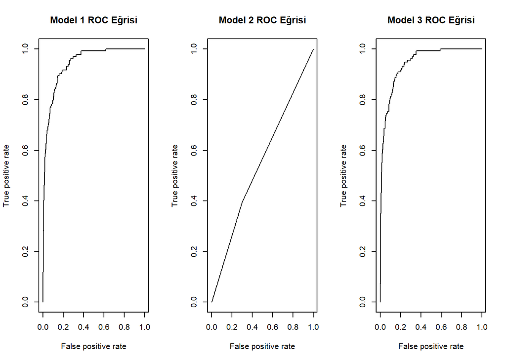

```r
# 1. Modelin ROC eğrisini çizme
par(mfrow=c(1, 3))

# Model 1 ROC eğrisini çizme
roc1 <- prediction(test.predicted.m1, test$default)
roc1_perf <- performance(roc1, measure = "tpr", x.measure = "fpr")
plot(roc1_perf, main="Model 1 ROC Eğrisi")

# Model 2 ROC eğrisini çizme
roc2 <- prediction(test.predicted.m2, test$default)
roc2_perf <- performance(roc2, measure = "tpr", x.measure = "fpr")
plot(roc2_perf, main="Model 2 ROC Eğrisi")

# Model 3 ROC eğrisini çizme
roc3 <- prediction(test.predicted.m3, test$default)
roc3_perf <- performance(roc3, measure = "tpr", x.measure = "fpr")
plot(roc3_perf, main="Model 3 ROC Eğrisi")
```

# Eğri altında kalan alanların hesaplanması

```r
# AUC (Eğri Altındaki Alan) hesaplaması
auc1 <- performance(roc1, measure = "auc")
auc2 <- performance(roc2, measure = "auc")
auc3 <- performance(roc3, measure = "auc")

# Model 1 AUC değeri
auc1_value <- auc1@y.values[[1]]
cat("Model 1 AUC: ", auc1_value, "\n")
```

```
## Model 1 AUC:  0.9432095
```

```r
# Model 2 AUC değeri
auc2_value <- auc2@y.values[[1]]
cat("Model 2 AUC: ", auc2_value, "\n")
```

```
## Model 2 AUC:  0.5481233
```

```r
# Model 3 AUC değeri
auc3_value <- auc3@y.values[[1]]
cat("Model 3 AUC: ", auc3_value, "\n")
```

```
## Model 3 AUC:  0.9450819
```

Model 1 ve Model 3: Bu iki model, AUC değerleri bakımından çok benzer sonuçlar veriyor ve her ikisi de yüksek AUC değerlerine sahip, bu da her iki modelin de çok iyi performans gösterdiğini ifade eder.

Model 2: Bu modelin AUC değeri 0.5 civarına çok yakın, yani neredeyse rastgele tahmin yapıyor. Bu, Model 2’nin kesinlikle geliştirilmesi gerektiğini gösterir. Model 2, gerçek dünya uygulamalarında güvenilmez olabilir.

Sonuç olarak, Model 1 ve Model 3, Model 2’den çok daha iyi performans gösteriyor.